# DATA624 Project-1

```r
kwh_arima <- Arima(kwh_ts, order=c(1,0,1), seasonal=c(0,1,2), lambda = BoxCox.lambda(kwh_ts))
summary(kwh_arima)
```

```
## Series: kwh_ts
## ARIMA(1,0,1)(0,1,2)[12]
## Box Cox transformation: lambda= -0.1454175
##
## Coefficients:
##          ar1      ma1     sma1    sma2
##       0.9475  -0.8014  -0.8016  0.1738
## s.e.  0.0838   0.1801   0.0933  0.0912
##
## sigma^2 = 8.786e-05:  log likelihood = 585.93
## AIC=-1161.86   AICc=-1161.51   BIC=-1145.89
##
## Training set error measures:
##                    ME     RMSE      MAE       MPE    MAPE      MASE      ACF1
## Training set 86012.57 597771.6 463632.2 0.8088744 7.00649 0.7783202 0.1518373
```

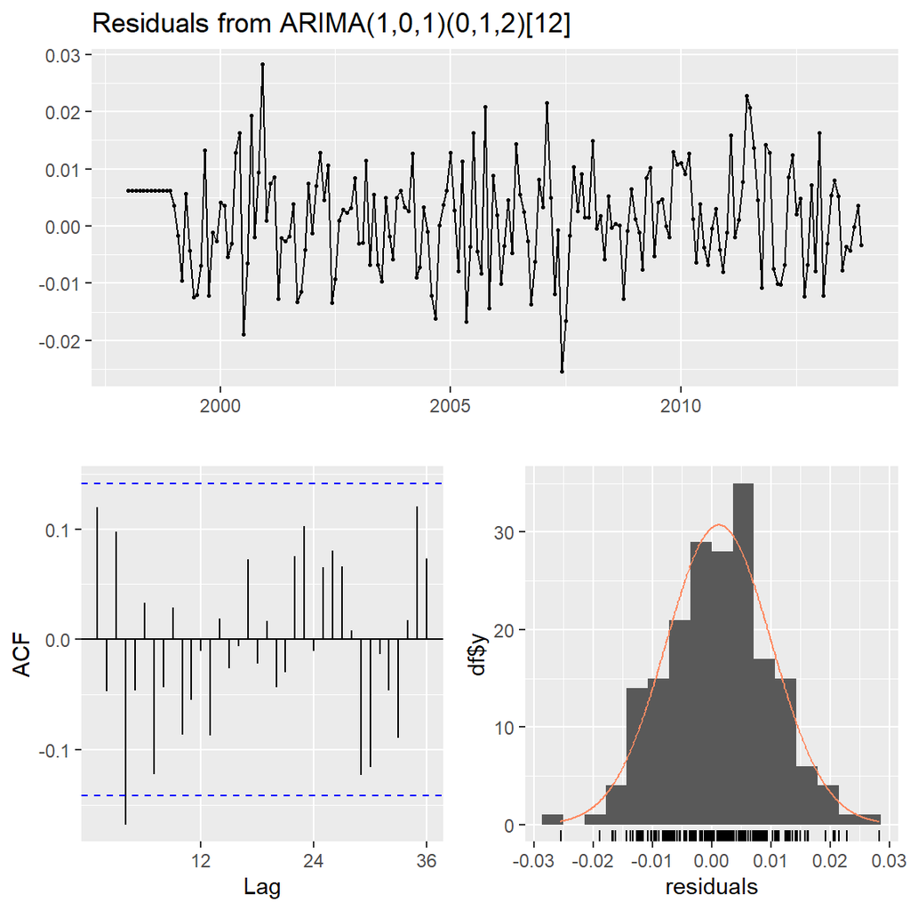

```
##
##  Ljung-Box test
##
## data:  Residuals from ARIMA(1,0,1)(0,1,2)[12]
## Q* = 24.322, df = 20, p-value = 0.2286
##
## Model df: 4.   Total lags used: 24
```

```r
checkresiduals(kwh_arima)
```

Now, let’s use auto.arima to find out which is the best Arima model:

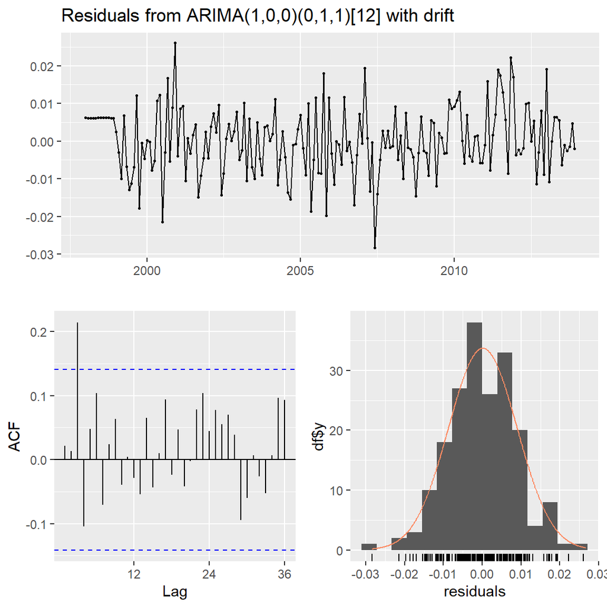

```
##
##  Ljung-Box test
##
## data:  Residuals from ARIMA(1,0,0)(0,1,1)[12] with drift
## Q* = 25.402, df = 22, p-value = 0.2782
##
## Model df: 2.   Total lags used: 24
```

```r
kwh_auto <- auto.arima(kwh_ts, approximation = FALSE, lambda=BoxCox.lambda(kwh_ts))
checkresiduals(kwh_auto)
```

```r
summary(kwh_auto)
```

```
## Series: kwh_ts
## ARIMA(1,0,0)(0,1,1)[12] with drift
## Box Cox transformation: lambda= -0.1454175
##
## Coefficients:
##          ar1     sma1  drift
##       0.2895  -0.7353  1e-04
## s.e.  0.0724   0.0700  1e-04
##
## sigma^2 = 8.429e-05:  log likelihood = 588.5
## AIC=-1169   AICc=-1168.77   BIC=-1156.23
##
## Training set error measures:
##                    ME     RMSE      MAE        MPE     MAPE      MASE
## Training set 20961.31 580774.8 445952.2 -0.2249688 6.812064 0.7486401
##                    ACF1
## Training set 0.05258332
```

The ARIMA model found by ‘auto.arima’ is ARIMA(1,0,0)(0,1,1)[12]. The ARIMA model I suggested is ARIMA(1,0,1)(0,1,2)[12]. According to the error measures and the residual plots, both models represents the data well with similar AIC values, similar error measures, and similar p-values. Both models can be applied, but the best Arima model is ARIMA(1,0,0)(0,1,1)[12], because it has a smaller AICc.

## Forecast

```r
kwh_model <- Arima(kwh_ts, order=c(1,0,0), seasonal=c(0,1,1), lambda = BoxCox.lambda(kwh_ts))
kwh_f <- forecast(kwh_model, h=12, level=95)
kwh_f
```

```
##          Point Forecast   Lo 95    Hi 95
## Jan 2014        9396883 7762540 11437614
## Feb 2014        7887475 6475039  9664189
## Mar 2014        6435175 5306104  7848082
## Apr 2014        5756155 4760036  6998419
## May 2014        5570691 4610683  6766688
## Jun 2014        7479517 6140217  9164205
## Jul 2014        8521791 6969852 10482565
## Aug 2014        9080655 7413299 11191835
## Sep 2014        7911892 6484811  9710387
## Oct 2014        5661786 4684004  6880566
## Nov 2014        5568723 4609087  6764249
## Dec 2014        6904666 5681062  8439739
```

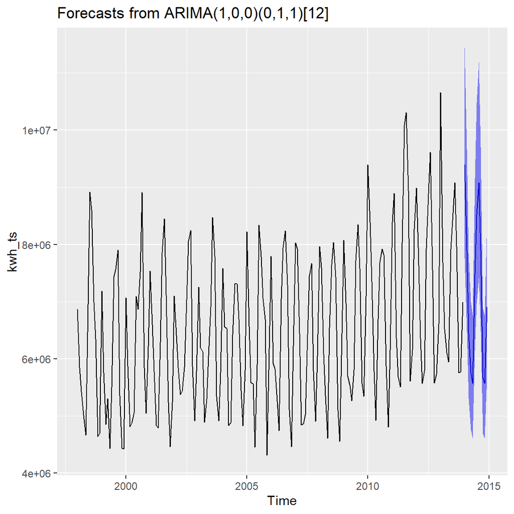

```r
autoplot(kwh_f)
```

```r
export <- kwh_f$mean
write.csv(export, "kwh_Forecast.csv")
```

We write the forecast data in the file: ‘kwh_Forecast.csv’

I think the forecast generated is accurate. Our forecast captures the seasonality of what appears to be increased demand in the summer and winter while falling between the peaks and troughs of more recent years..

# Part C– BONUS, optional (part or all)

## Objetive

The goal of the project is to explore time series, decomposition, forecasting, data preprocessing, exponential smoothing, and ARIMA.

## Load Data

Load the excel data:

```r
wfp1 <- import("https://raw.githubusercontent.com/GabrielSantos33/DATA624_Project1/main/Waterflow_Pipe1.xlsx", col_types = c("date", "numeric"))
wfp2 <- import("https://raw.githubusercontent.com/GabrielSantos33/DATA624_Project1/main/Waterflow_Pipe2.xlsx", col_types = c("date", "numeric"))
colnames(wfp1) <- c("DateTime", "WaterFlow")
colnames(wfp2) <- c("DateTime", "WaterFlow")
```

Match the hour with wfp2:

```r
wfp1 <- wfp1 %>% mutate(Date = as.Date(DateTime), Time = hour(DateTime)+1) %>%
                  group_by(Date, Time) %>%
                  summarise(Water=mean(WaterFlow)) %>%
                  ungroup() %>%
                  mutate(DateTime=ymd_h(paste(Date,Time))) %>%
                  select(DateTime,Water)
wfp1
```

```
## # A tibble: 236 × 2
##    DateTime            Water
##    <dttm>              <dbl>
##  1 2015-10-23 01:00:00  26.1
##  2 2015-10-23 02:00:00  18.9
##  3 2015-10-23 03:00:00  15.2
##  4 2015-10-23 04:00:00  23.1
##  5 2015-10-23 05:00:00  15.5
##  6 2015-10-23 06:00:00  22.7
##  7 2015-10-23 07:00:00  20.6
##  8 2015-10-23 08:00:00  18.4
##  9 2015-10-23 09:00:00  20.8
## 10 2015-10-23 10:00:00  21.2
## # … with 226 more rows
```

```r
wfp2 <- wfp2 %>% mutate(Date = as.Date(DateTime), Time = hour(DateTime)) %>%
                  group_by(Date, Time) %>%
                  summarise(Water=mean(WaterFlow)) %>%
                  ungroup() %>%
                  mutate(DateTime=ymd_h(paste(Date,Time))) %>%
                  select(DateTime, Water)
wfp2
```

```
## # A tibble: 1,000 × 2
##    DateTime            Water
##    <dttm>              <dbl>
##  1 2015-10-23 01:00:00 18.8
##  2 2015-10-23 02:00:00 43.1
##  3 2015-10-23 03:00:00 38.0
##  4 2015-10-23 04:00:00 36.1
##  5 2015-10-23 05:00:00 31.9
##  6 2015-10-23 06:00:00 28.2
##  7 2015-10-23 07:00:00  9.86
##  8 2015-10-23 08:00:00 26.7
##  9 2015-10-23 09:00:00 55.8
## 10 2015-10-23 10:00:00 54.2
## # … with 990 more rows
```

## Timeseries

Combining the two waterflows into one:

```r
water <- full_join(wfp1, wfp2, by="DateTime", suffix=c("_1", "_2")) %>%
  mutate(Water_1=ifelse(is.na(Water_1), 0, Water_1)) %>%
  mutate(Water_2=ifelse(is.na(Water_2), 0, Water_2)) %>%
  mutate(Water = Water_1 + Water_2) %>%
  select(DateTime, Water)
water
```

```
## # A tibble: 1,000 × 2
##    DateTime            Water
##    <dttm>              <dbl>
##  1 2015-10-23 01:00:00  44.9
##  2 2015-10-23 02:00:00  61.9
##  3 2015-10-23 03:00:00  53.1
##  4 2015-10-23 04:00:00  59.2
##  5 2015-10-23 05:00:00  47.3
##  6 2015-10-23 06:00:00  51.0
##  7 2015-10-23 07:00:00  30.5
##  8 2015-10-23 08:00:00  45.0
##  9 2015-10-23 09:00:00  76.6
## 10 2015-10-23 10:00:00  75.4
## # … with 990 more rows
```

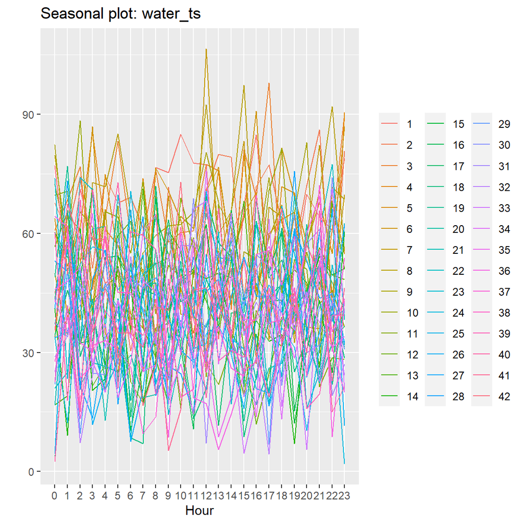

```r
water_ts <- ts(water$Water, frequency=24)
ggseasonplot(water_ts) + theme(legend.title = element_blank())
```

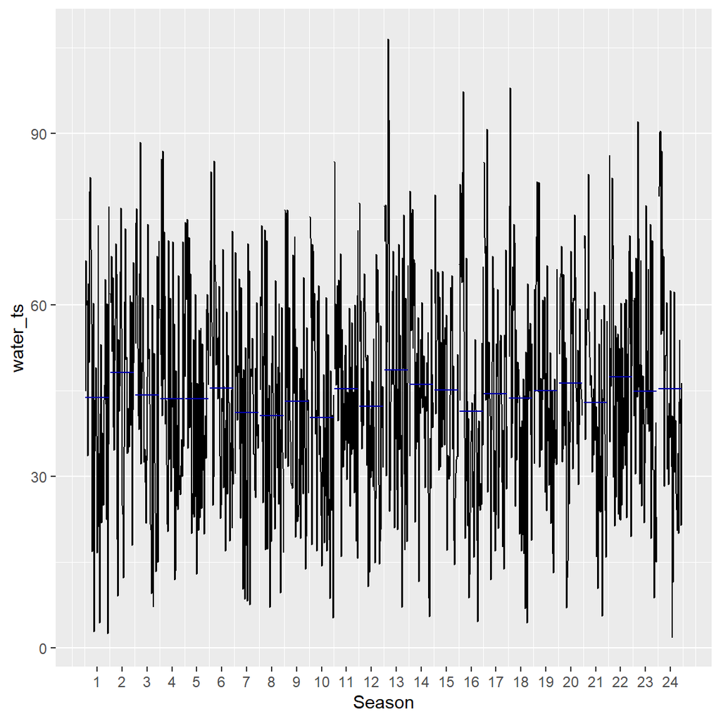

```r
ggsubseriesplot(water_ts)
```

We cannot see significant seasonality involved in ‘water_ts’ however there is a slightly decreasing trend. It is a non-stationary timeseries.

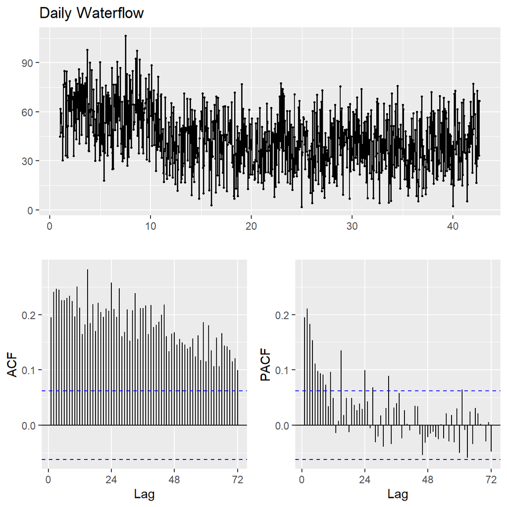

```r
water_ts <- ts(water$Water, frequency=24)
ggtsdisplay(water_ts, main="Daily Waterflow")
```

## ARIMA Model

We apply BocCox transformation:

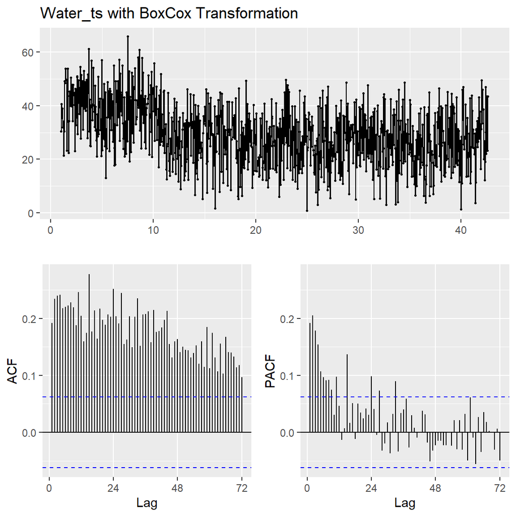

```r
water_bc <- BoxCox(water_ts, lambda = BoxCox.lambda(water_ts))
ggtsdisplay(water_bc, main="Water_ts with BoxCox Transformation")
```

Trend differencing is needed.

```r
ndiffs(water_ts)
```

```
## [1] 1
```

```r
nsdiffs(water_ts)
```

```
## [1] 0
```

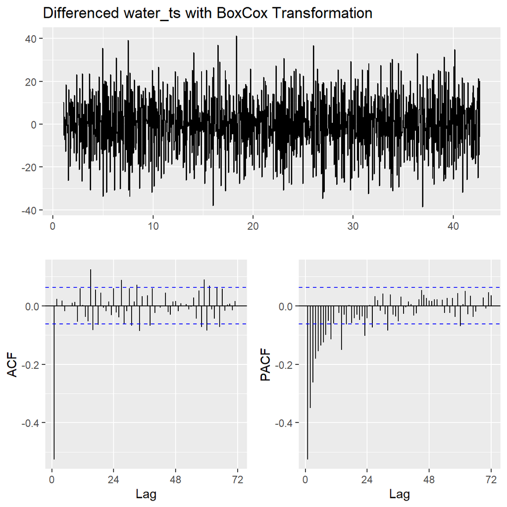

```r
ggtsdisplay(diff(water_bc), points=FALSE, main="Differenced water_ts with BoxCox Transformation")
```

```r
water_bc %>% diff() %>% ur.kpss() %>% summary()
```

```
##
## #######################
## # KPSS Unit Root Test #
## #######################
##
## Test is of type: mu with 7 lags.
##
## Value of test-statistic is: 0.0091
##
## Critical value for a significance level of:
##                 10pct  5pct 2.5pct  1pct
## critical values 0.347 0.463  0.574 0.739
```

```r
water_arima <- Arima(water_ts, order=c(0,1,1), seasonal=c(0,0,1), lambda = BoxCox.lambda(water_ts))
summary(water_arima)
```

```
## Series: water_ts
## ARIMA(0,1,1)(0,0,1)[24]
## Box Cox transformation: lambda= 0.8713037
##
## Coefficients:
##           ma1    sma1
##       -0.9578  0.0712
## s.e.   0.0101  0.0319
##
## sigma^2 = 103.3:  log likelihood = -3734.4
## AIC=7474.8   AICc=7474.83   BIC=7489.52
##
## Training set error measures:
##                     ME     RMSE      MAE       MPE     MAPE      MASE
## Training set 0.1591549 16.33716 13.34589 -28.20783 50.26558 0.7507364
##                     ACF1
## Training set -0.04444759
```

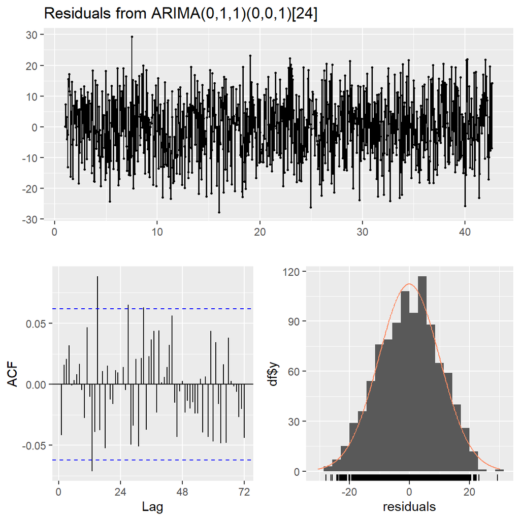

```
##
##  Ljung-Box test
##
## data:  Residuals from ARIMA(0,1,1)(0,0,1)[24]
## Q* = 57.881, df = 46, p-value = 0.1124
##
## Model df: 2.   Total lags used: 48
```

```r
checkresiduals(water_arima)
```

Now, let’s use auto.arima to find out which is the best Arima model:

```r
water_auto <- auto.arima(water_ts, approximation = FALSE, lambda=BoxCox.lambda(water_ts))
summary(water_auto)
```

```
## Series: water_ts
## ARIMA(0,1,1)(1,0,0)[24]
## Box Cox transformation: lambda= 0.8713037
##
## Coefficients:
##           ma1    sar1
##       -0.9578  0.0714
## s.e.   0.0101  0.0322
##
## sigma^2 = 103.3:  log likelihood = -3734.4
## AIC=7474.8   AICc=7474.82   BIC=7489.52
##
## Training set error measures:
##                     ME     RMSE      MAE       MPE     MAPE     MASE
## Training set 0.1613506 16.33729 13.34564 -28.19083 50.25213 0.750722
##                     ACF1
## Training set -0.04431537
```

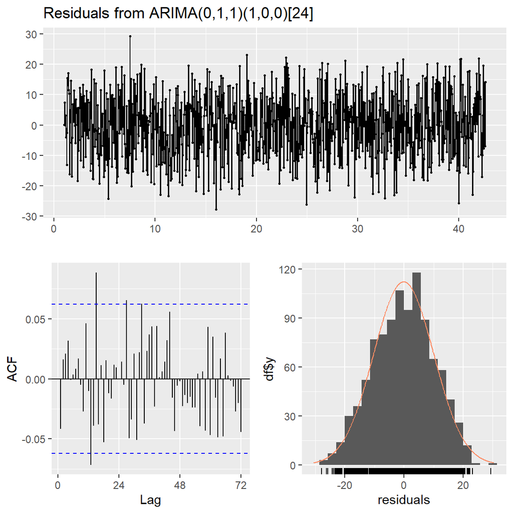

```
##
##  Ljung-Box test
##
## data:  Residuals from ARIMA(0,1,1)(1,0,0)[24]
## Q* = 57.858, df = 46, p-value = 0.1128
##
## Model df: 2.   Total lags used: 48
```

```r
checkresiduals(water_auto)
```

The ARIMA model found by ‘auto.arima’ is ARIMA(0,1,1)(1,0,0)[24].The ARIMA model I suggested is ARIMA(0,1,1)(0,0,1)[24].Both models are similars to each other, on the statistics with only 0.01 difference on AICc. I will use the model generated by ‘auto.arima’, ARIMA(0,1,1)(1,0,0)[24].

```r
water_model <- Arima(water_ts, order=c(0,1,1), seasonal=c(1,0,0), lambda = BoxCox.lambda(water_ts))
```

## Forecast

I performed the forecast on a week on water use, 7 days, for 24 hours.

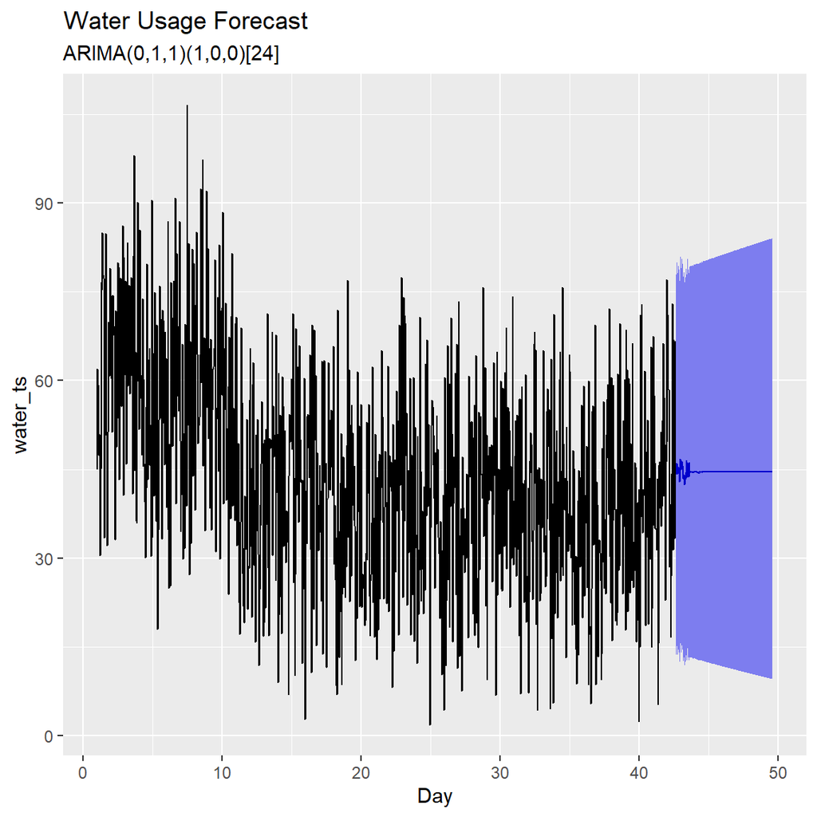

```r
water_f <- forecast(water_model, h=7*24, level=95)
autoplot(water_f) +
  labs(title="Water Usage Forecast", subtitle = "ARIMA(0,1,1)(1,0,0)[24]", x="Day")
```

```r
export <- water_f$mean
write.csv(export, "Waterflow_Forecast.csv")
df <- data.frame(water_f) %>% select(Point.Forecast)
rownames(df) <- NULL
df
```

```
##     Point.Forecast
## 1         44.13862
## 2         45.16903
## 3         46.07068
## 4         44.27144
## 5         45.44000
## 6         44.89509
## 7         42.95309
## 8         44.67901
## 9         46.80433
## 10        44.92962
## 11        46.40268
## 12        45.53528
## 13        45.54120
## 14        43.38716
```

[output cut: 154 more lines]

Let’s generate the forecast data in the file ‘Waterflow_Forecast.csv’.

I think that the forecast generated, allowing us to see what the water flow will be is not reliable, because we can see that it does not follow the pattern of the data. I think it’s because its large, the forecasts are closer to the mean.